# Plants

Luke Nash

2023-08-27

**Pre-requisite packages**

```r
library(ggplot2)
library(ggpubr)
library(broom)
library(plyr)
library(dplyr)
library(plotrix)
library(readxl)
library(stats)
library(tidyr)
library(glue)
library(sparklyr)
library(DescTools)
library(MVN)
library(energy)
library(npmv)
```

## Introduction

This project is looking at the effects of salt concentration on the growth and proliferation of three ecotypes of *Arabidopsis thaliana*. For more information about the data collection, and some background information about the scientific context of this project, please read the README in the [GitHub repository for this project](https://github.com/LukeNash28/ArabidopsisExploration).

For now, let’s load and do some initial processing on the collected data. The data is imported from an Excel file as a data frame.

We’re only interested in a few columns, so we can use `subset` to remove the unnecessary columns.

```r
Plants<-subset(Plants,select=c(Ecotype,Salt_Conc.,Combination,Root_Length,Rosette_Width,Leaf_no.,Lateral_root_no.))
head(Plants)
```

```
##   Ecotype Salt_Conc. Combination Root_Length Rosette_Width Leaf_no.
## 1     ZuO          0       ZuO-0          22            11        8
## 2     ZuO          0       ZuO-0          23             8        5
## 3     ZuO          0       ZuO-0          28             9        8
## 4     ZuO          0       ZuO-0          13             8        3
## 5     ZuO          0       ZuO-0          44            17       11
## 6     ZuO          0       ZuO-0          65            22       11
##   Lateral_root_no.
## 1                6
## 2                2
## 3                7
## 4                2
## 5               16
## 6               12
```

#### Descriptive Statistics

Let’s look at the data’s structure first so we know what we’re dealing with.

```r
str(Plants)
```

```
## 'data.frame':    1455 obs. of  7 variables:
##  $ Ecotype         : chr  "ZuO" "ZuO" "ZuO" "ZuO" ...
##  $ Salt_Conc.      : num  0 0 0 0 0 0 0 0 0 0 ...
##  $ Combination     : chr  "ZuO-0" "ZuO-0" "ZuO-0" "ZuO-0" ...
##  $ Root_Length     : num  22 23 28 13 44 65 32 20 45 3 ...
##  $ Rosette_Width   : num  11 8 9 8 17 22 11 4 27 5 ...
##  $ Leaf_no.        : num  8 5 8 3 11 11 9 4 11 2 ...
##  $ Lateral_root_no.: num  6 2 7 2 16 12 8 1 15 0 ...
```

```r
names(Plants)
```

```
## [1] "Ecotype"          "Salt_Conc."       "Combination"      "Root_Length"
## [5] "Rosette_Width"    "Leaf_no."         "Lateral_root_no."
```

In this project we had four dependent variables - root length, rosette width, leaf number and lateral root number. Let’s have a look at the summary statistics for each of those.

```r
PlantsDep<-subset(Plants,select=c(Root_Length,Rosette_Width,Leaf_no.,Lateral_root_no.))
PlantsSummary<- PlantsDep %>%
  summarise(across(everything(), list(mean=mean,std_deviation=sd, variance=var)))
print(PlantsSummary)
```

```
##   Root_Length_mean Root_Length_std_deviation Root_Length_variance
## 1         20.13024                  18.31603              335.477
##   Rosette_Width_mean Rosette_Width_std_deviation Rosette_Width_variance
## 1           8.035395                    6.518592               42.49204
##   Leaf_no._mean Leaf_no._std_deviation Leaf_no._variance Lateral_root_no._mean
## 1      5.498969               3.367429          11.33958              5.156014
##   Lateral_root_no._std_deviation Lateral_root_no._variance
## 1                       6.848206                  46.89793
```

All these metrics have relatively high degree of variation in the data, with the standard deviations being 91%, 81%, 61% and 132.8% of the mean for root length, rosette width, leaf number and lateral root number respectively.

One reason why they may be so high is because the data incorporates both the conditions (no salt and salt applied) as well as all three of the ecotypes. Consequently let’s group the data by salt, then ecotype, then a combination of the two.

```r
#Create vectors for loops to iterate through
Conditions<-c('Ecotype','Salt_Conc.','Combination')
Measurements<-c('Root_Length','Rosette_Width','Leaf_no.','Lateral_root_no.')
Results<-list() #Object to append results of the iterations to.

#Nested for loop to iterate through conditions and measurements
for (col in Conditions) {
  for (measure in Measurements) {
    result<- Plants %>%
      group_by_at(col) %>%
      summarise(Mean = mean(!!sym(measure)),
                SD = sd(!!sym(measure)),
                PSD = Mean + SD,
                NSD = Mean - SD) %>%
      mutate(across(where(is.numeric),~round(.,2)))
    result_name <- paste(col,measure,sep=",")
    Results[[result_name]]<-result
  }
}
print(Results)
```

```
## $`Ecotype,Root_Length`
## # A tibble: 3 × 5
##   Ecotype  Mean    SD   PSD   NSD
##   <chr>   <dbl> <dbl> <dbl> <dbl>
## 1 Col      22.8  21.2  43.9  1.56
## 2 Sha      19.6  16.6  36.1  2.97
## 3 ZuO      17.8  16.0  33.8  1.75
##
## $`Ecotype,Rosette_Width`
## # A tibble: 3 × 5
##   Ecotype  Mean    SD   PSD   NSD
##   <chr>   <dbl> <dbl> <dbl> <dbl>
## 1 Col      9.04  7.35  16.4  1.69
## 2 Sha      7.95  6.5   14.4  1.45
## 3 ZuO      7.01  5.29  12.3  1.72
##
## $`Ecotype,Leaf_no.`
## # A tibble: 3 × 5
##   Ecotype  Mean    SD   PSD   NSD
##   <chr>   <dbl> <dbl> <dbl> <dbl>
## 1 Col      5.82  3.57  9.39  2.25
## 2 Sha      5.39  3.45  8.84  1.95
## 3 ZuO      5.25  3.01  8.26  2.23
##
## $`Ecotype,Lateral_root_no.`
## # A tibble: 3 × 5
##   Ecotype  Mean    SD   PSD   NSD
##   <chr>   <dbl> <dbl> <dbl> <dbl>
## 1 Col      6.03  8    14.0  -1.97
## 2 Sha      5.19  6.73 11.9  -1.54
## 3 ZuO      4.16  5.27  9.43 -1.12
##
## $`Salt_Conc.,Root_Length`
## # A tibble: 2 × 5
##   Salt_Conc.  Mean    SD   PSD   NSD
##        <dbl> <dbl> <dbl> <dbl> <dbl>
## 1          0 29.8  18.9   48.6 10.9
## 2         50  8.68  8.31  17.0  0.37
##
## $`Salt_Conc.,Rosette_Width`
```

[output cut: 48 more lines]

```
## 3 Sha-0        7     3.43 10.4   3.57
## 4 Sha-50       3.14  1.84  4.98  1.3
## 5 ZuO-0        6.77  3.17  9.94  3.6
## 6 ZuO-50       3.74  1.89  5.62  1.85
##
## $`Combination,Lateral_root_no.`
## # A tibble: 6 × 5
##   Combination  Mean    SD   PSD   NSD
##   <chr>       <dbl> <dbl> <dbl> <dbl>
## 1 Col-0        9.65  9.17 18.8   0.48
## 2 Col-50       1.67  2.29  3.96 -0.62
## 3 Sha-0        7.58  7.72 15.3  -0.14
## 4 Sha-50       1.83  2.45  4.28 -0.62
## 5 ZuO-0        6.05  5.95 12     0.09
## 6 ZuO-50       2.28  3.64  5.92 -1.36
```

The standard deviations are still very high to the extent that in some cases the NSD value is negative, which for all of these measures is impossible - a plant can’t have -1.36 lateral roots!

As a result, standard deviation is not much use for plotting purposes. Consequently, we will use standard error instead.

```r
Results=c()

for (col in Conditions) {
  for (measure in Measurements) {
    result<- Plants %>%
      group_by_at(col) %>%
      summarise(!!glue("{measure}_Mean") := mean(!!sym(measure)),
                !!glue("{measure}_SE") := std.error(!!sym(measure)),
                !!glue("{measure}_PSE") := mean(!!sym(measure)) + std.error(!!sym(measure)),
                !!glue("{measure}_NSE") := mean(!!sym(measure)) - std.error(!!sym(measure))) %>%
      mutate(across(where(is.numeric),~round(.,2)))
    result_name <- paste(col,measure,sep=",")
    Results[[result_name]]<-result
  }
}
```

### Data Visualisation

```r
#Left join all the tibbles in Results for each of Ecotype, Salt Conc. and Combination
CombinedResults=c()

for (condition in Conditions) {
  col_dfs<-lapply(Measurements, function(measure) Results[[paste(condition, measure,sep=",")]])
  col_df<- join_all(col_dfs, by= condition, type="left")

  combined_name<-paste(condition,"df", sep="_")
  CombinedResults[[combined_name]] <- col_df
}
```

Then partition the combined tibbles into separate data frames for each independent variable.

```r
for (name in names(CombinedResults)) {
  assign(name, CombinedResults[[name]])
}
```

Now let’s look at the graphs for each independent variable, starting with Ecotype.

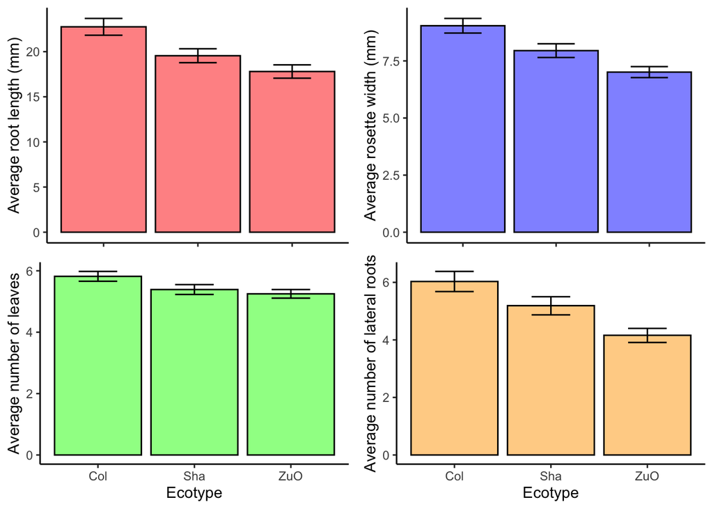

```r
RootEco<-ggplot(Ecotype_df,aes(x=Ecotype,y=Root_Length_Mean))+
  geom_bar(position="dodge",stat="identity",colour="black",fill="red",alpha=0.5)+
  geom_errorbar(aes(x=Ecotype,ymin=Root_Length_NSE,ymax=Root_Length_PSE),width=0.4, position=position_dodge(width=0.9))+
  xlab("Ecotype")+
  ylab("Average root length (mm)")+
  theme(axis.title.y=element_text(size=9))+
  theme_classic()

RosetteEco<-ggplot(Ecotype_df,aes(x=Ecotype,y=Rosette_Width_Mean))+
  geom_bar(position="dodge",stat="identity",colour="black",fill="blue",alpha=0.5)+
  geom_errorbar(aes(x=Ecotype,ymin=Rosette_Width_NSE,ymax=Rosette_Width_PSE),width=0.4, position=position_dodge(width=0.9))+
  xlab("Ecotype")+
  ylab("Average rosette width (mm)")+
  theme(axis.title.y=element_text(size=9))+
  theme_classic()

LeafEco<-ggplot(Ecotype_df,aes(x=Ecotype,y=Leaf_no._Mean))+
  geom_bar(position="dodge",stat="identity",colour="black",fill="green",alpha=0.5)+
  geom_errorbar(aes(x=Ecotype,ymin=Leaf_no._NSE,ymax=Leaf_no._PSE),width=0.4, position=position_dodge(width=0.9))+
  xlab("Ecotype")+
  ylab("Average number of leaves")+
  theme(axis.title.y=element_text(size=9))+
  theme_classic()

LatRootEco<-ggplot(Ecotype_df,aes(x=Ecotype,y=Lateral_root_no._Mean))+
  geom_bar(position="dodge",stat="identity",colour="black",fill="orange",alpha=0.5)+
  geom_errorbar(aes(x=Ecotype,ymin=Lateral_root_no._NSE,ymax=Lateral_root_no._PSE),width=0.4, position=position_dodge(width=0.9))+
  xlab("Ecotype")+
  ylab("Average number of lateral roots")+
  theme(axis.title.y=element_text(size=9))+
  theme_classic()

EcotypeComposite<-ggarrange(RootEco+rremove("x.title")+rremove("x.text"),
          RosetteEco+rremove("x.title")+rremove("x.text"),
          LeafEco,
          LatRootEco,
          common.legend=TRUE,
          legend="right",
          ncol=2,nrow=2,
          font.label=list(size=16),
          hjust=c(-0.5,0.7,-0.5,0.7),
          vjust=c(1.5,1.5,0.5,0.5))

print(EcotypeComposite)
```

As you can see, the size ranking of each of the three ecotypes is consistent across all four measurements, with ZuO being the lowest followed by Sha and then Col.

Now let’s look at salt concentration. For the sake of brevity, I will be omitting the code used to create this graph as the coding process is very similar and has already been established. The one exception is converting the `Salt_Conc.` to a factor (discrete).

```r
Salt_Conc._df$Salt_Conc.<-as.factor(Salt_Conc._df$Salt_Conc.)
```

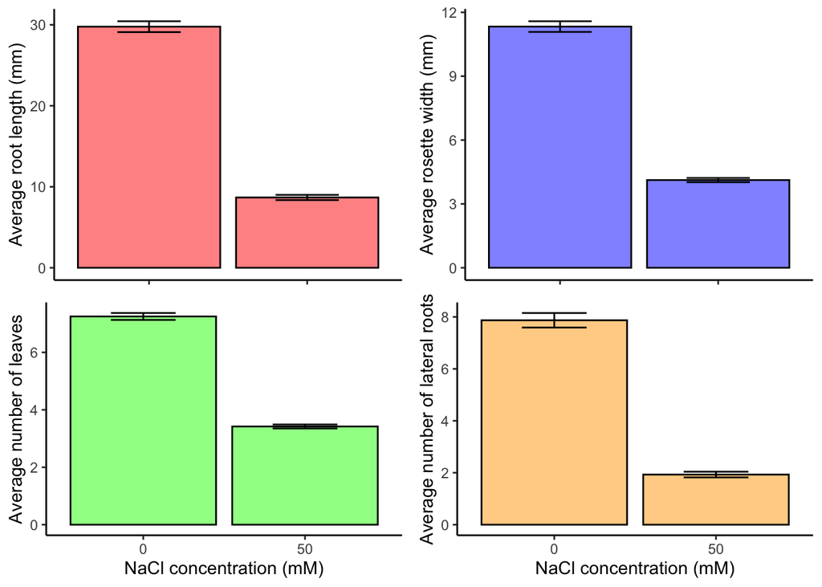

Perhaps unsurprisingly, the plants growing in saline conditions grew far less well than the ones with no salt.

Finally, let’s look at the Combination.

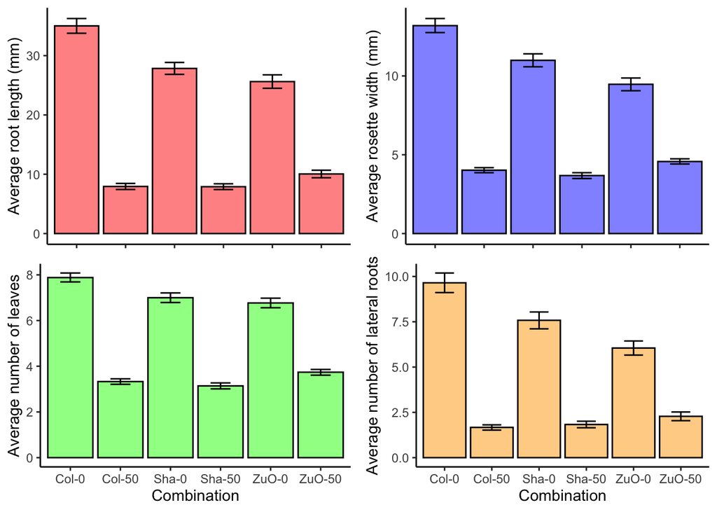

This mostly tells us the same thing as before about the hierarchy in the sizes of the ecotypes and the significant growth stunting in saline conditions.

I’m going to present one more figure of a bar chart of Ecotype vs each measurement of size but grouped by Salt Concentration, but this will require our data to be formatted slightly differently.

```r
#Processing the data
Plant_grouped<- Plants %>%
  group_by(Combination) %>%
  summarise(across(
    Root_Length:Lateral_root_no.,
    list(
      M= ~mean(.),
      PSE= ~mean(.)+ std.error(.),
      NSE= ~mean(.)- std.error(.)
    )
  )) %>%
  mutate(across(where(is.numeric),~round(.,2)))

Plant_grouped<-data.frame(Plant_grouped)
Type<-c("Col","Col","Sha","Sha","ZuO","ZuO")
Salt<-rep(c(0,50),3)
Plant_grouped<-data.frame(Type,Salt,Plant_grouped[-1])
Plant_grouped$Salt<-as.factor(Plant_grouped$Salt)
print(Plant_grouped)
```

```
##   Type Salt Root_Length_M Root_Length_PSE Root_Length_NSE Rosette_Width_M
## 1  Col    0         35.01           36.25           33.77           13.19
## 2  Col   50          7.94            8.45            7.43            4.02
## 3  Sha    0         27.84           28.85           26.84           10.99
## 4  Sha   50          7.90            8.39            7.42            3.68
## 5  ZuO    0         25.62           26.76           24.49            9.47
## 6  ZuO   50         10.05           10.68            9.41            4.57
##   Rosette_Width_PSE Rosette_Width_NSE Leaf_no._M Leaf_no._PSE Leaf_no._NSE
## 1             13.64             12.75       7.88         8.08         7.69
## 2              4.18              3.86       3.33         3.45         3.21
## 3             11.40             10.58       7.00         7.21         6.79
## 4              3.86              3.49       3.14         3.27         3.01
## 5              9.87              9.06       6.77         6.98         6.56
## 6              4.74              4.41       3.74         3.86         3.61
##   Lateral_root_no._M Lateral_root_no._PSE Lateral_root_no._NSE
## 1               9.65                10.19                 9.11
## 2               1.67                 1.81                 1.52
## 3               7.58                 8.04                 7.11
## 4               1.83                 2.01                 1.65
## 5               6.05                 6.44                 5.66
## 6               2.28                 2.52                 2.04
```

This is now in the right format for plotting.

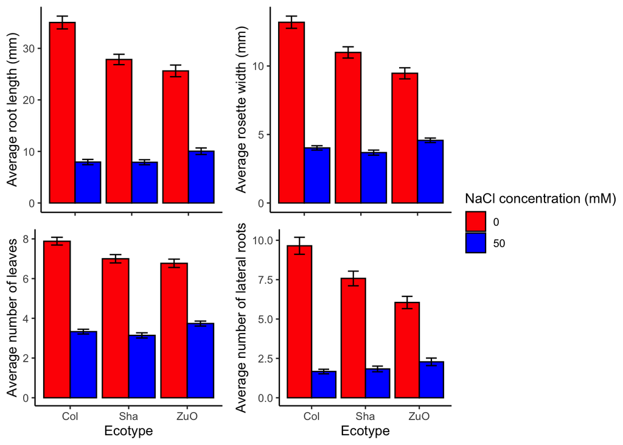

```r
RootGrouped<-ggplot(Plant_grouped,aes(fill=Salt,x=Type,y=Root_Length_M,group=Salt))+
  geom_bar(position="dodge",stat="identity",colour="black")+
  geom_errorbar(aes(x=Type, ymin=Root_Length_NSE,ymax=Root_Length_PSE),width=0.4,position=position_dodge(width=0.9))+
  xlab("Ecotype")+
  ylab("Average root length (mm)")+
  theme(axis.title.y=element_text(size=9))+
  scale_fill_manual(values=c("red","blue"),name="NaCl concentration (mM)")+
  theme_classic()

RosetteGrouped<-ggplot(Plant_grouped,aes(fill=Salt,x=Type,y=Rosette_Width_M,group=Salt))+
  geom_bar(position="dodge",stat="identity",colour="black")+
  geom_errorbar(aes(x=Type, ymin=Rosette_Width_NSE,ymax=Rosette_Width_PSE),width=0.4,
                position=position_dodge(width=0.9))+
  xlab("Ecotype")+
  ylab("Average rosette width (mm)")+
  scale_fill_manual(values=c("red","blue"),name="NaCl concentration (mM)")+
  theme(axis.title.y=element_text(size=9))+
  theme_classic()

LeafGrouped<-ggplot(Plant_grouped,aes(fill=Salt,x=Type,y=Leaf_no._M,group=Salt))+
  geom_bar(position="dodge",stat="identity",colour="black")+
  geom_errorbar(aes(x=Type, ymin=Leaf_no._NSE,ymax=Leaf_no._PSE),width=0.4,
                position=position_dodge(width=0.9))+
  xlab("Ecotype")+
  ylab("Average number of leaves")+
  scale_fill_manual(values=c("red","blue"),name="NaCl concentration (mM)")+
  theme(axis.title.y=element_text(size=9))+
  theme_classic()

LatRootGrouped<-ggplot(Plant_grouped,aes(fill=Salt,x=Type,y=Lateral_root_no._M,group=Salt))+
  geom_bar(position="dodge",stat="identity",colour="black")+
  geom_errorbar(aes(x=Type, ymin=Lateral_root_no._NSE,ymax=Lateral_root_no._PSE),width=0.4,
                position=position_dodge(width=0.9))+
  xlab("Ecotype")+
  ylab("Average number of lateral roots")+
  scale_fill_manual(values=c("red","blue"),name="NaCl concentration (mM)")+
  theme(axis.title.y=element_text(size=9))+
  theme_classic()

GroupedComposite<-ggarrange(RootGrouped+rremove("x.title")+rremove("x.text"),
          RosetteGrouped+rremove("x.title")+rremove("x.text"),
          LeafGrouped,
          LatRootGrouped,
          common.legend=TRUE,
          legend="right",
          ncol=2,nrow=2,
          font.label=list(size=16),
          hjust=c(-0.5,0.7,-0.5,0.7),
          vjust=c(1.5,1.5,0.5,0.5))

print(GroupedComposite)
```

This shows something quite interesting: the size hierarchy in non-saline conditions (Col > Sha > ZuO) is either partially or entirely reversed, suggesting that **the extent to which the ecotypes are affected by salinity is different**.

### Diagnostic Statistics

When looking at ecotype, since we have a categorical variable influencing multiple dependent variables, we need a form of multivariate ANOVA. However, after carrying out a Mardia’s multivariate normality test, the four measurements do not show any normality.

```r
Variates<-Plants[-c(1:3)]
mvn(data=Variates,mvnTest="mardia")
```

```
## $multivariateNormality
##              Test        Statistic p value Result
## 1 Mardia Skewness 4309.55869137088       0     NO
## 2 Mardia Kurtosis 100.548463318884       0     NO
## 3             MVN             <NA>    <NA>     NO
##
## $univariateNormality
##               Test         Variable Statistic   p value Normality
## 1 Anderson-Darling   Root_Length      49.6880  <0.001      NO
## 2 Anderson-Darling  Rosette_Width     86.1654  <0.001      NO
## 3 Anderson-Darling     Leaf_no.       33.3852  <0.001      NO
## 4 Anderson-Darling Lateral_root_no.  104.4339  <0.001      NO
##
## $Descriptives
##                     n      Mean   Std.Dev Median Min Max 25th 75th      Skew
## Root_Length      1455 20.130241 18.316031     15   0  92    4   31 1.0687062
## Rosette_Width    1455  8.035395  6.518592      6   0  31    3   11 1.2604682
## Leaf_no.         1455  5.498969  3.367429      5   0  24    2    8 0.8197088
## Lateral_root_no. 1455  5.156014  6.848206      3   0  51    0    7 2.5060394
##                   Kurtosis
## Root_Length      0.5908956
## Rosette_Width    0.6792120
## Leaf_no.         0.7106128
## Lateral_root_no. 8.4988177
```

Therefore, we will use a very recently developed non-parametric version of the MANOVA. It has performed very well according to the very select few people who’ve used it and has stood up to “multivariate data which usually involve different, typically dependent characteristics measured in rather different units.” according to the authors. It is available through the `npmv` package.

```r
nonpartest(Root_Length | Rosette_Width | Leaf_no. | Lateral_root_no. ~ Ecotype, data=Plants, permreps=1000,plots=FALSE)
```

```
## $results
##                                                   Test Statistic   df1      df2
## ANOVA type test p-value                                    4.214 2.615 1893.596
## McKeon approx. for the Lawley Hotelling Test               2.989 8.000 2067.675
## Muller approx. for the Bartlett-Nanda-Pillai Test          2.985 8.017 2903.989
## Wilks Lambda                                               2.987 8.000 2898.000
##                                                   P-value
## ANOVA type test p-value                             0.008
## McKeon approx. for the Lawley Hotelling Test        0.002
## Muller approx. for the Bartlett-Nanda-Pillai Test   0.002
## Wilks Lambda                                        0.002
##                                                   Permutation Test p-value
## ANOVA type test p-value                                              0.010
## McKeon approx. for the Lawley Hotelling Test                         0.002
## Muller approx. for the Bartlett-Nanda-Pillai Test                    0.002
## Wilks Lambda                                                         0.002
##
## $releffects
##     Root_Length Rosette_Width Leaf_no. Lateral_root_no.
## Col     0.52382       0.52753  0.52344          0.52418
## Sha     0.50389       0.49201  0.48830          0.50920
## ZuO     0.46975       0.47736  0.48556          0.46411
```

For the salt concentration, we can perform a Hotelling’s T<sup>2</sup> test, as shown below.

*NOTE: The only package offering non-parametric multiple comparisons equivalent to a multivariate Mann-Whitney test is no longer maintained, so we are going to have to bypass this assumption. Central Limit Theorem dictates that normality can be assumed owing to the sample size involved, but this is obviously not ideal.*

```r
#Preparing the data
Plants_sub<-Plants[-c(1,3)]
`0_conc`=subset(Plants_sub,Salt_Conc.== 0)
`50_conc`= subset(Plants_sub,Salt_Conc.== 50)
`0_conc`<-`0_conc`[-1]
`50_conc`<-`50_conc`[-1]

#Performing the test
HotellingsT2Test(x=`0_conc`,y=`50_conc`)
```

```
##
##  Hotelling's two sample T2-test
##
## data:  0_conc and 50_conc
## T.2 = 206.58, df1 = 4, df2 = 1450, p-value < 2.2e-16
## alternative hypothesis: true location difference is not equal to c(0,0,0,0)
```

### Conclusions

Based on the tests and visualisations carried out above, we can draw the following conclusions with a relatively high degree of confidence:

- The growth of each of the three ecotypes was different.
- Salt had a tangible impact on the growth of plants of all ecotypes, but…
- Some ecotypes respond to salinity better than other ecotypes.

To read more about the data collection and some evaluation points of the protocol, please read the README file in the [GitHub repository for this project](https://github.com/LukeNash28/ArabidopsisExploration).